# 개미 '김일반'의 재테크 일기

아침에 일어난 김일반씨.. 평소처럼 신문을 읽는다.

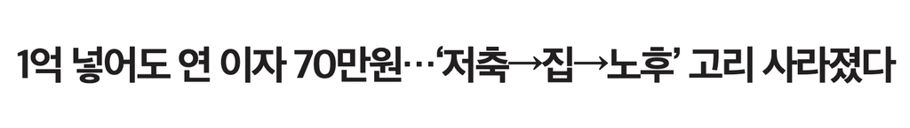

> 자산 증식 길이 막힌 청년층의 신음이 커지고 있다. 은행권의 예금 금리가 또 한 번 사상 최저치를 경신하면서다. 한국은행에 따르면 8월 예금은행의 저축성 수신금리(신규취급액 기준)는 연 0.81%로 집계됐다. 6월(0.89%) 0%대에 진입한 이후 석 달 연속 하락이다. 8월에 새로 가입한 정기예금 가운데 84.3%의 금리가 1%에 못 미쳤다. 신종 코로나바이러스 감염증(코로나19) 확산에 따른 경제적 충격을 방어하기 위해 기준금리를 낮춘 여파다. 한은은 올해 들어 연 1.25%였던 기준금리를 0.50%까지 인하했다.

> 32세 직장인 김도엽 씨는 수도권 신도시 아파트에서 전세로 산다. 보증금 2억7000만원 중 부모님이 1억원가량을 지원했고, 나머지는 부부가 모은 돈으로 마련했다. 다행히 빚은 없다. 현재 부부가 생활비 등을 제외하고 1년 동안 모을 수 있는 돈의 최대치는 2500만원. 주로 적금을 활용하는데 이자가 적어 거의 원금만 쌓는 수준이다. 김씨는 “내년쯤 아이를 가질 계획인데 지출이 많이 늘 것이고, 돈 모으기 더 힘들어질 것 같아 두렵다”며 “보장성 보험을 제외하곤 노후 준비 같은 건 생각도 못 한다”고 말했다.

출처: [중앙일보] https://news.joins.com/article/23898407

> 끝없이 낮아지는 금리.. 하늘 높은 줄 모르고 올라가는 집값.. 이 두가지가 시너지를 일으키며 많은 청년들에게 '깜깜한 미래'를 선물(??)하고 있다.  
> 과연 자신의 돈만으로 집을 사는 신혼부부가 몇이나 될까? 근로소득이 엄청 높지 않은 이상, 대다수가 은행에 대출을 받거나 부모님에게 지원을 받는다.  
> 그렇다면.. 행복해야할 신혼 부부들이 '빚'으로 시작하거나 지원해준 부모님의 노후준비에 '적신호'가 들어올 것이다.

예/적금만으로 돈을 모으던 '김일반'에게 충격적인 기사였다. 재테크에 대해 아무것도 모르는 '김일반'씨는 유튜브에 '재테크'를 쳐본다. 많은 영상들이 나온다.  
주식/펀드/ETF에 관한 영상이 많다. '주식 아직 안하세요?', '20 **년 주목해야할 주식', '지금 당장 시작해라' 등 자극적인 제목이 김일반 씨의 마음을 흔든다.**  
'늦었다' 라는 생각에 준비도 하지 않은 채, 재테크 세계로 뛰어든 김일반 씨.. 그의 미래는 밝을까?**

## 예/적금 & 주식 & 펀드 & ETF 비교하기

김일반씨는 재테크에 대해 아무것도 모르는 상황이다.  
주식/ETF/펀드를 별 고민없이 규모가 큰 기업, 잘 알려진, 우리에게 익숙한 기업에 매월 10만원씩 투자하였다고 한다.  
막무가내 재테크를 5년 동안 지속하였을 때, 과연 예/적금 수익률보다 다른 재테크 수단의 수익률이 높을까?

### 예/적금

먼저, 예적금 수익률을 보자. '김일반'씨는 1년 만기 적금상품을 선택했다. 만기된 적금을 수령하면 그 금액을 고스란히 정기예금에 넣는다고 한다.

|  | 날짜 | 적금이자 | 예금이자 |
| --- | --- | --- | --- |
| 0 | 2020-10-15 | 2.39 | 1.81 |
| 1 | 2019-10-15 | 2.61 | 2.40 |
| 2 | 2018-10-15 | 2.70 | 2.64 |
| 3 | 2017-10-15 | 2.57 | 2.34 |
| 4 | 2016-10-15 | 2.66 | 2.05 |
| 5 | 2015-10-15 | 2.79 | 2.06 |

- 정기예금, 정기적금 연도별 평균 이자율 / 출처: [저축은행중앙회](https://www.fsb.or.kr/ratedepo_0100.act)

적금 이자가 2.39라 해서 매월 넣는 납입금액에 똑같이 2.39%만큼의 이자가 붙는 것이 아니다.  
처음 넣은 금액만 2.39%만큼의 이자가 붙고, 나머지는 예치기간에 따라 이자율 점점 더 작아진다.  
ex) 1차납입: 2.39 *12(예치기간)/12(계약기간), 2차납입: 2.39*11(예치기간)/12(계약기간), 3차납입: 2.3910(예치기간)/12(계약기간).....  
그럼 만기 적금액은 어떻게 계산할까?  
**적금 실제 이자율 = 적금 연 이자율 × (만기 개월 수 + 1) ÷ 24**  
**수령액 = 월부금 계약개월 * 적금 실제 이자율**  
위의 식을 쓰면 간단한다. 정기예금의 경우, 처음 납입금액에 이자율만큼 이자가 붙기 때문에 계산하기 간단하다.  
자!! 이제, '김일반'씨의 5년 뒤 수익률을 계산해보자.

```
def saving_output(input_money, interest):
    real_interest = interest*13/24
    output_money = 12*input_money*(1+real_interest/100)
    return output_money

def deposit_output(input_money, interest):
    output_money = input_money*(1+interest/100)
    return output_money

total_money = 0
input_money = 100000

for idx, row in bank.iterrows():
    saving = saving_output(input_money, float(row['적금이자']))
    deposit = deposit_output(total_money, float(row['예금이자']))

    total_money = saving + deposit

print(f'5년 뒤, 김일반씨 손에 들어올 금액은 "{round(total_money)}원" 입니다')
```

```
5년 뒤, 김일반씨 손에 들어올 금액은 "7718658원" 입니다
```

### 주식

'김일반'씨는 시가총액 1위 '삼성전자'주식을 사기로 한다. 달마다 10만원씩 주식계좌에 넣으며, 주식을 사고 남은 차액은 다음달 납입금과 더해 주식을 더 매수하였다.  
(2015년, 삼성전자 주식은 백만원이 넘었다(액면분할 전).. '김일반'씨가 사지못하는 주식이지만,, 수익률 비교를 위해서 액면분할했다고 가정하여 원래가격에 50을 나누어주었다.)

|  | 날짜 | 시가 | 종가 |
| --- | --- | --- | --- |
| 0 | 2015-10-19 | 25140.0 | 25120.0 |
| 1 | 2015-11-13 | 26340.0 | 26000.0 |
| 2 | 2015-12-15 | 25220.0 | 25540.0 |
| 3 | 2016-01-14 | 22620.0 | 22760.0 |
| 4 | 2016-02-15 | 23080.0 | 23080.0 |
| ... | ... | ... | ... |
| 56 | 2020-06-15 | 51400.0 | 49900.0 |
| 57 | 2020-07-16 | 54800.0 | 53800.0 |
| 58 | 2020-08-14 | 58000.0 | 58000.0 |
| 59 | 2020-09-15 | 60900.0 | 61000.0 |
| 60 | 2020-10-15 | 60700.0 | 60000.0 |

61 rows × 3 columns

- 삼성전자 날짜별 주식가격 / 출처: [네이버 금융](https://finance.naver.com/item/sise.nhn?code=005930)

'김일반'씨는 시가에 사서 종가에 팔았다. 계산하기 편하게.. 5년 뒤 수익률을 계산해보자!!

```
def buy_stock(input_money, stock_price):
    buying_stock = math.trunc(input_money / stock_price)
    return buying_stock

def receive_change(input_money, buying_stock, stock_price):
    having_change = input_money - (stock_price * buying_stock)
    return having_change

input_money = 100000
having_stock = 0
having_change = 0

for idx, row in df2.iterrows():
    total_money = having_change + input_money

    buying_stock = buy_stock(total_money, row['시가'])
    having_stock += buying_stock

    having_change = receive_change(total_money, buying_stock, row['시가'])

print(f'5년 뒤, 김일반씨 손에 들어올 금액은 "{round(row["종가"] * having_stock)}원" 입니다')
```

```
5년 뒤, 김일반씨 손에 들어올 금액은 "9000000원" 입니다
```

### ETF

'김일반'씨는 국가대표 ETF라 할 수 있는 '코덱스 200' ETF에 투자하기로 했다. 방법은 주식 투자와 똑같다.  
코덱스 200의 추종지수는 KOSPI200이다. 쉽게 말해 잘나가는 종목 200개의 추세에 투자한 것이다.

|  | 날짜 | 종가 | 전일비 | 시가 | 고가 | 저가 | 거래량 |
| --- | --- | --- | --- | --- | --- | --- | --- |
| 0 | 2015-10-19 | 24770.0 | 10.0 | 24825.0 | 24860.0 | 24660.0 | 5332612.0 |
| 1 | 2015-11-13 | 24250.0 | 340.0 | 24325.0 | 24405.0 | 24250.0 | 3819027.0 |
| 2 | 2015-12-15 | 23940.0 | 45.0 | 23985.0 | 24030.0 | 23875.0 | 5300412.0 |
| 3 | 2016-01-14 | 23535.0 | 225.0 | 23490.0 | 23535.0 | 23315.0 | 11743773.0 |
| 4 | 2016-02-15 | 23240.0 | 300.0 | 23180.0 | 23305.0 | 23130.0 | 11780526.0 |
| ... | ... | ... | ... | ... | ... | ... | ... |
| 56 | 2020-06-15 | 26700.0 | 1415.0 | 27800.0 | 28025.0 | 26700.0 | 19839278.0 |
| 57 | 2020-07-16 | 29005.0 | 320.0 | 29325.0 | 29340.0 | 28920.0 | 7683914.0 |
| 58 | 2020-08-14 | 31920.0 | 340.0 | 32215.0 | 32255.0 | 31635.0 | 9653402.0 |
| 59 | 2020-09-15 | 32280.0 | 250.0 | 32135.0 | 32310.0 | 32005.0 | 10677521.0 |
| 60 | 2020-10-15 | 31415.0 | 235.0 | 31595.0 | 31625.0 | 31275.0 | 7091175.0 |

61 rows × 7 columns

- 코덱스 200 날짜별 ETF 가격 / 출처: [네이버 금융](http://finance.naver.com/item/sise_day.nhn?code=069500)

```
def buy_ETF(input_money, ETF_price):
    buying_ETF = math.trunc(input_money / ETF_price)
    return buying_ETF

def receive_change(input_money, buying_ETF, ETF_price):
    having_change = input_money - (ETF_price * buying_ETF)
    return having_change

input_money = 100000
having_ETF = 0
having_change = 0

for idx, row in df2.iterrows():
    total_money = having_change + input_money

    buying_ETF = buy_ETF(total_money, row['시가'])
    having_ETF += buying_ETF
    having_change = receive_change(total_money, buying_ETF, row['시가'])

# 10/15 기준, 종가로 총 평가금액 계산.
print(f'5년 뒤, 김일반씨 손에 들어올 금액은 "{round(row["종가"] * having_ETF)}원" 입니다')
```

```
5년 뒤, 김일반씨 손에 들어올 금액은 "6848470원" 입니다
```

### 펀드

'김일반'씨는 펀드투자를 하기로 마음먹었다. 펀드를 찾아보기로 한다.

|  | itemname | itemcode |
| --- | --- | --- |
| 0 | 한화 코리아레전드4차산업혁명증권자투자신탁(주식)S | KR5103587782 |
| 1 | 한화 코리아레전드4차산업혁명증권자투자신탁(주식)S-P | KR5103587782 |
| 2 | 미래에셋 차이나디스커버리증권투자신탁1호 (주식) S | KR5301520486 |
| 3 | 프랭클린 선택과집중증권투자신탁 (주식) S | KR5217AO9905 |
| 4 | AB 미국그로스증권투자신탁 (주식-재간접형) S | KR5370199287 |
| ... | ... | ... |
| 2073 | 키움 아세안성장에이스증권자투자신탁[주식]C-Pe | K55206BY8574 |
| 2074 | 키움 코스닥SmartInvestor분할매수증권투자신탁제1호[혼합-재간접형]C-Pe | K55206C66777 |
| 2075 | 신한BNPP 에너지인덱스플러스자투자신탁제1호[채권-파생형](종류A-e) | KR5210AM6694 |
| 2076 | 블랙록 월드에너지증권자투자신탁(주식-재간접)(UH)C-Pe | K55366BU9762 |
| 2077 | 키움 장대트리플플러스증권투자신탁1호 [채권혼합]C-Pe | K55206CE5490 |

2078 rows × 2 columns

펀드 종류가 너무 많다. 펀드이름이 무엇을 의미하는지 모르겠다.  
머리가 아파지기 시작한 그는.. 몇년 전부터 자주 들리던 '4차 산업헉명'이란 단어에 꽂혔다.  
그 순간, '김일반'씨는 한화 코리아레전드4차산업혁명증권자투자신탁(주식)' 펀드를 사기로 결정하였다.(이렇게 투자하시면 안돼요..)

|  | 날짜 | 기준가 | 전일대비 | 등락율 (%) | 설정액 (억) | 순 자산액(억) | 과표기준가 |
| --- | --- | --- | --- | --- | --- | --- | --- |
| 0 | 2015-10-15 | 1087.68 | 7.43 | -0.68 | 89 | 97 | 987.08 |
| 1 | 2015-11-13 | 1078.01 | 4.31 | 0.40 | 88 | 95 | 985.43 |
| 2 | 2015-12-15 | 1075.52 | 11.75 | -1.08 | 88 | 95 | 983.59 |
| 3 | 2016-01-14 | 1010.93 | 18.79 | 1.89 | 97 | 98 | 1010.26 |
| 4 | 2016-02-15 | 953.52 | 17.04 | -1.76 | 97 | 92 | 1008.88 |
| ... | ... | ... | ... | ... | ... | ... | ... |
| 56 | 2020-06-15 | 1090.50 | 11.38 | -1.03 | 37 | 41 | 993.82 |
| 57 | 2020-07-16 | 1194.99 | 7.36 | 0.62 | 37 | 44 | 993.76 |
| 58 | 2020-08-14 | 1346.29 | 13.57 | -1.00 | 37 | 49 | 992.06 |
| 59 | 2020-09-15 | 1396.82 | 8.84 | 0.64 | 37 | 52 | 990.08 |
| 60 | 2020-10-15 | 1370.07 | 9.29 | -0.67 | 37 | 51 | 989.87 |

61 rows × 7 columns

- 날짜별 한화 코리아레전드4차산업혁명증권자투자신탁(주식) 가격표 / 출처: [네이버 금융](https://finance.naver.com/fund/fundDailyQuoteList.nhn?fundCd=KR5103587782)

한달에 10만원씩 펀드를 매수해 나갔다. 5년 후, 그의 수익률은 얼마일까?

```
def buy_FUND(input_money, FUND_price):
    buying_FUND = math.trunc(input_money / FUND_price)
    return buying_FUND

def receive_change(input_money, buying_FUND, FUND_price):
    having_change = input_money - (FUND_price * buying_FUND)
    return having_change

input_money = 100000
having_FUND = 0
having_change = 0

for idx, row in df2.iterrows():
    total_money = having_change + input_money

    buying_FUND = buy_FUND(total_money, row['기준가'])
    having_FUND += buying_FUND

    having_change = receive_change(total_money, buying_FUND, row['기준가'])

print(f'5년 뒤, 김일반씨 손에 들어올 금액은 "{round(row["기준가"] * having_FUND)}원" 입니다')
```

```
5년 뒤, 김일반씨 손에 들어올 금액은 "8157397원" 입니다
```

모든 재테크에는 '선택'과 '책임'이 필수적이다.

> 'High risk, High return'

주식시장에 급하게 뛰어든 '우리들' 중 위의 말을 정확히 이해하고 있는 사람이 몇이나 될까??  
'영끌','빚투' 기사가 많은 것을 보니, 많은 사람들이 'High return'에 정신이 팔린 채 'High risk'를 잊는거 같다.

김일반씨도 선택을 잘못하였다면, 일반씨의 수익률은 ETF(10%),펀드(0%),주식(-20%).. 이었을 것이다.  
예/적금보다 낮은 수익률임은 물론이고 원금조차 보존하지 못하였다는 말이다.